# Estimating $R_0$ and other parameters for the COVID-19 epidemic in the US

April 02, 2020

## Parameters

### Summary

The epidemiology of COVID-19 in the US is poorly understood. Identifying the key processes that shape transmission and estimating the relevant model parameters is therefore an important task. This document presents arguments and analysis to support the estimation of a number of key quantities.

Findings are preliminary and subject to change, pending future changes in the underlying data. Results have not been peer-reviewed, but have been prepared to a professional standard with the intention of providing useful information about a rapidly developing event.

Key parameters to be investigated in this document include:

- Epidemic curve
- Incubation period ($1/\sigma$)
- Isolation rate ($1/\gamma$)
- Symptom onset to reporting
- Reporting date to death
- Sex and age

### Data

Key resources used for this investigation include:

A ``line list’’ maintained by CEID containing case level information in the US, including start dates for key individual events (presentation of symptoms, hospitalization, case notification, etc.)

Note: This data set is being actively updated as we find more information.

### Epidemic curve

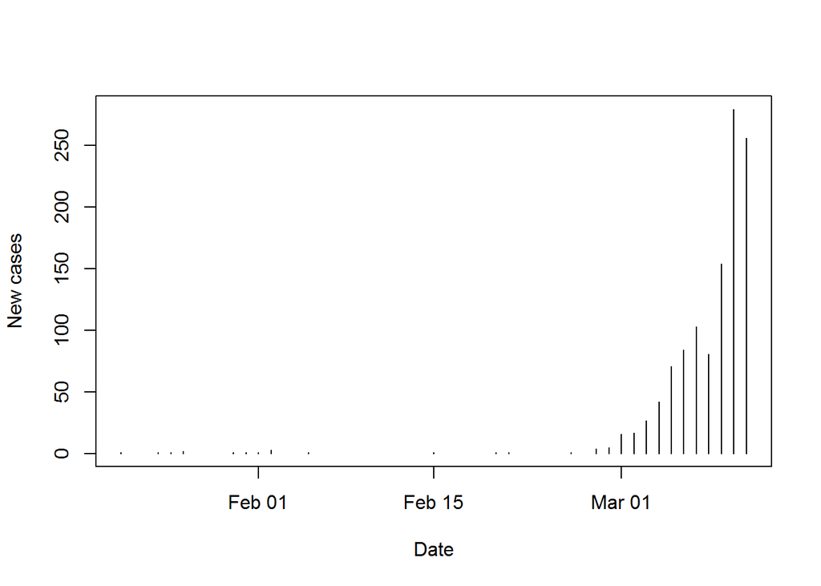

### Incubation period

Current information about incubation period in the US.

| count | Date_symptoms | Exposure_end | inc_period |
| --- | --- | --- | --- |
| 1 | 2020-03-11 | 2020-03-11 | 0 |
| 2 | 2020-02-29 | 2020-02-21 | 8 |
| 3 | 2020-02-25 | 2020-02-22 | 3 |
| 4 | 2020-02-27 | 2020-02-22 | 5 |
| 5 | 2020-03-01 | 2020-02-21 | 9 |
| 6 | 2020-03-09 | 2020-03-07 | 2 |
| 7 | 2020-03-02 | 2020-02-27 | 4 |
| 8 | 2020-03-03 | 2020-02-20 | 12 |
| 9 | 2020-03-03 | 2020-02-20 | 12 |
| 10 | 2020-03-03 | 2020-02-20 | 12 |
| 11 | 2020-03-07 | 2020-03-06 | 1 |
| 12 | 2020-03-05 | 2020-02-25 | 9 |
| 13 | 2020-02-29 | 2020-02-23 | 6 |
| 14 | 2020-03-08 | 2020-03-04 | 4 |
| 15 | 2020-01-19 | 2020-01-15 | 4 |
| 16 | 2020-03-12 | 2020-03-08 | 4 |
| 17 | 2020-03-17 | 2020-03-08 | 9 |
| 18 | 2020-03-12 | 2020-03-07 | 5 |
| 19 | 2020-02-26 | 2020-02-22 | 4 |

```
## [1] "gamma distribution for incubation period: "
```

```
##      shape       rate
##   2.9628967   0.4719658
##  (0.9373582) (0.1626992)
```

```
## [1] "exponential distribution for incubation period: "
```

```
##       rate
##   0.16814159
##  (0.03857433)
```

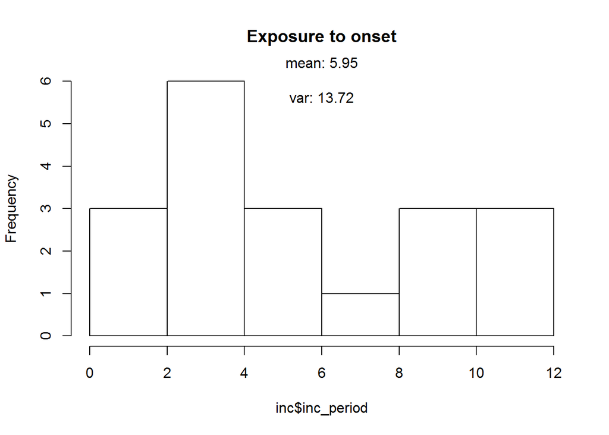

### Isolation rate

Current information in our dataset about time from symptom onset to hospitalization.

| count | Date_symptoms | Date_hospital | iso_period |
| --- | --- | --- | --- |
| 1 | 2020-03-11 | 2020-03-12 | 1 |
| 2 | 2020-03-03 | 2020-03-03 | 0 |
| 3 | 2020-03-08 | 2020-03-09 | 1 |
| 4 | 2020-02-29 | 2020-03-03 | 3 |
| 5 | 2020-03-02 | 2020-03-07 | 5 |
| 6 | 2020-02-28 | 2020-03-13 | 14 |
| 7 | 2020-02-25 | 2020-03-05 | 9 |
| 8 | 2020-03-02 | 2020-03-08 | 6 |
| 9 | 2020-02-28 | 2020-03-09 | 10 |
| 10 | 2020-03-06 | 2020-03-10 | 4 |
| 11 | 2020-03-05 | 2020-03-09 | 4 |
| 12 | 2020-03-11 | 2020-03-15 | 4 |
| 13 | 2020-02-22 | 2020-02-27 | 5 |
| 14 | 2020-02-28 | 2020-03-05 | 6 |
| 15 | 2020-03-05 | 2020-03-11 | 6 |
| 16 | 2020-01-19 | 2020-01-19 | 0 |
| 17 | 2020-03-12 | 2020-03-14 | 2 |
| 18 | 2020-03-13 | 2020-03-17 | 4 |

```
## [1] "gamma distribution for isolation period of values >0: "
```

```
##      shape       rate
##   2.4648660   0.4694987
##  (0.8193549) (0.1730496)
```

```
## [1] "exponential distribution for isolation period: "
```

```
##       rate
##   0.21428571
##  (0.05050763)
```

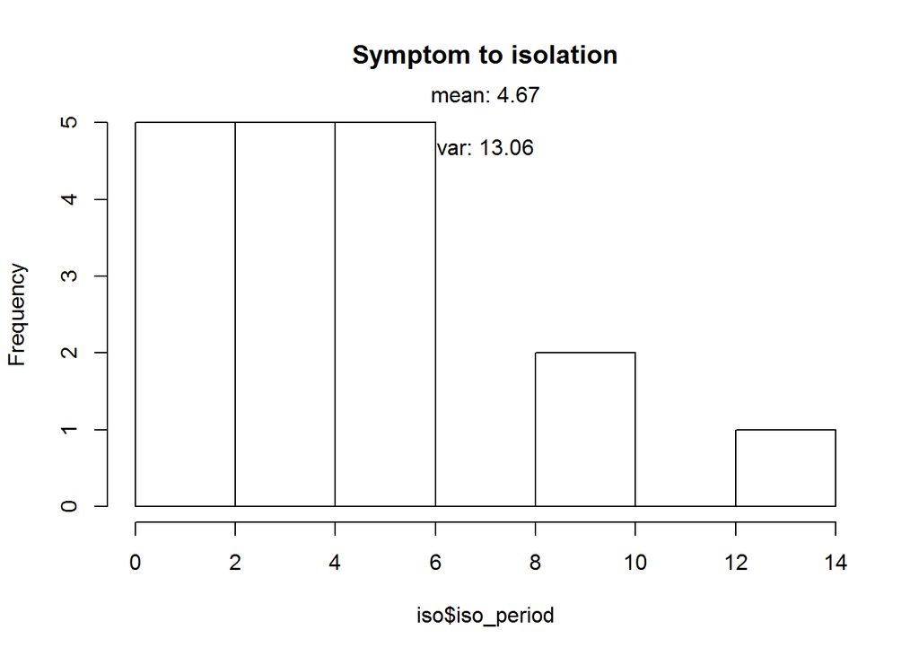

### Onset -> reports

Current information in our dataset about time from symptom onset to reporting.

| count | Date_symptoms | Date_reported | rep_period |
| --- | --- | --- | --- |
| 1 | 2020-03-11 | 2020-03-12 | 1 |
| 2 | 2020-02-29 | 2020-03-03 | 3 |
| 3 | 2020-03-03 | 2020-03-05 | 2 |
| 4 | 2020-03-08 | 2020-03-12 | 4 |
| 5 | 2020-02-24 | 2020-03-07 | 12 |
| 6 | 2020-02-25 | 2020-03-02 | 6 |
| 7 | 2020-02-27 | 2020-03-02 | 4 |
| 8 | 2020-02-29 | 2020-03-06 | 6 |
| 9 | 2020-03-01 | 2020-03-06 | 5 |
| 10 | 2020-03-02 | 2020-03-08 | 6 |
| 11 | 2020-03-09 | 2020-03-15 | 6 |
| 12 | 2020-03-09 | 2020-03-15 | 6 |
| 13 | 2020-03-02 | 2020-03-06 | 4 |
| 14 | 2020-03-01 | 2020-03-08 | 7 |
| 15 | 2020-02-28 | 2020-03-15 | 16 |
| 16 | 2020-03-01 | 2020-03-07 | 6 |
| 17 | 2020-03-03 | 2020-03-05 | 2 |
| 18 | 2020-03-03 | 2020-03-05 | 2 |
| 19 | 2020-03-03 | 2020-03-05 | 2 |
| 20 | 2020-02-25 | 2020-03-06 | 10 |
| 21 | 2020-03-02 | 2020-03-08 | 6 |
| 22 | 2020-02-28 | 2020-03-10 | 11 |
| 23 | 2020-03-06 | 2020-03-11 | 5 |
| 24 | 2020-03-05 | 2020-03-11 | 6 |
| 25 | 2020-03-07 | 2020-03-12 | 5 |
| 26 | 2020-03-05 | 2020-03-06 | 1 |
| 27 | 2020-03-11 | 2020-03-18 | 7 |
| 28 | 2020-02-22 | 2020-03-03 | 10 |
| 29 | 2020-02-24 | 2020-03-13 | 18 |
| 30 | 2020-03-10 | 2020-03-14 | 4 |
| 31 | 2020-03-02 | 2020-03-14 | 12 |
| 32 | 2020-02-29 | 2020-03-06 | 6 |
| 33 | 2020-02-19 | 2020-02-28 | 9 |
| 34 | 2020-03-11 | 2020-03-11 | 0 |
| 35 | 2020-02-28 | 2020-03-08 | 9 |
| 36 | 2020-03-07 | 2020-03-09 | 2 |
| 37 | 2020-03-08 | 2020-03-11 | 3 |
| 38 | 2020-03-02 | 2020-03-12 | 10 |
| 39 | 2020-03-03 | 2020-03-13 | 10 |
| 40 | 2020-03-05 | 2020-03-13 | 8 |
| 41 | 2020-01-19 | 2020-01-21 | 2 |
| 42 | 2020-02-27 | 2020-02-28 | 1 |
| 43 | 2020-03-12 | 2020-03-17 | 5 |
| 44 | 2020-03-17 | 2020-03-21 | 4 |
| 45 | 2020-03-12 | 2020-03-15 | 3 |
| 46 | 2020-02-26 | 2020-03-07 | 10 |

```
## [1] "gamma distribution for reporting period of values >0: "
```

```
##      shape         rate
##   2.42133507   0.39335782
##  (0.47946796) (0.08652821)
```

```
## [1] "exponential distribution for reporting period: "
```

```
##       rate
##   0.16606498
##  (0.02448495)
```

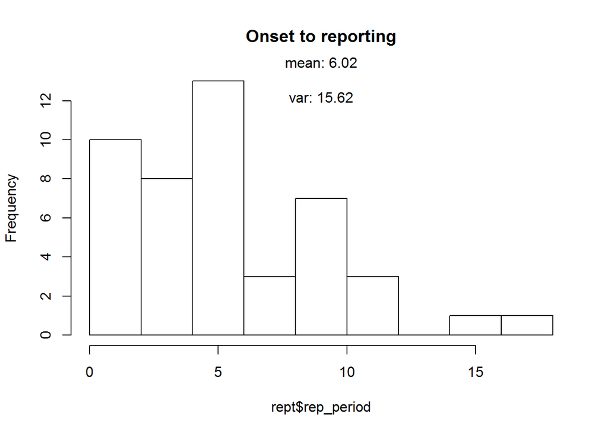

### Reporting -> Death

A skew normal distribution is used due to a few negative reporting to death intervals.

The univariate skew normal distribution has a density function that can be written

$f(y)=2\phi(y)\Phi(\alpha y)$

where $\alpha$ is the shape parameter. Here, $\phi$ is the standard normal density and $\phi$ its cumulative distribution function. When $\alpha$=0 the result is a standard normal distribution. When $\alpha$=1 it models the distribution of the maximum of two independent standard normal variates. When the absolute value of the shape parameter increases the skewness of the distribution increases. The limit as the shape parameter tends to positive infinity results in the folded normal distribution or half normal distribution. When the shape parameter changes its sign, the density is reflected about y=0.

The mean of the distribution is $\mu=\alpha\sqrt 2/(\pi (1+\alpha^2))$

and these are returned as the fitted values. The variance of the distribution is $1-\mu^2$. The Newton Raphson algorithm is used unless the nsimEIM argument is used.

Current information in our dataset about time from reporting to death. Some values are negative because death was assigned post-mortem.

| count | State | Date_reported | Date_death | rep_period |
| --- | --- | --- | --- | --- |
| 1 | California | 2020-02-28 | 2020-03-09 | 10 |
| 2 | California | 2020-03-04 | 2020-03-04 | 0 |
| 3 | California | 2020-03-10 | 2020-03-10 | 0 |
| 4 | Colorado | 2020-03-13 | 2020-03-13 | 0 |
| 5 | District of Columbia | 2020-03-11 | 2020-03-20 | 9 |
| 6 | District of Columbia | 2020-03-18 | 2020-03-21 | 3 |
| 7 | District of Columbia | 2020-03-24 | 2020-03-25 | 1 |
| 8 | District of Columbia | 2020-03-26 | 2020-03-27 | 1 |
| 9 | Florida | 2020-03-05 | 2020-03-06 | 1 |
| 10 | Florida | 2020-03-06 | 2020-03-06 | 0 |
| 11 | Georgia | 2020-03-07 | 2020-03-12 | 5 |
| 12 | Georgia | 2020-03-12 | 2020-03-18 | 6 |
| 13 | Georgia | 2020-03-15 | 2020-03-18 | 3 |
| 14 | Georgia | 2020-03-15 | 2020-03-18 | 3 |
| 15 | Georgia | 2020-03-15 | 2020-03-19 | 4 |
| 16 | Georgia | 2020-03-15 | 2020-03-19 | 4 |
| 17 | Georgia | 2020-03-19 | 2020-03-19 | 0 |
| 18 | Indiana | 2020-03-10 | 2020-03-17 | 7 |
| 19 | Indiana | 2020-03-11 | 2020-03-16 | 5 |
| 20 | Kansas | 2020-03-12 | 2020-03-11 | -1 |
| 21 | Kentucky | 2020-03-13 | 2020-03-16 | 3 |
| 22 | Louisiana | 2020-03-11 | 2020-03-14 | 3 |
| 23 | Louisiana | 2020-03-11 | 2020-03-16 | 5 |
| 24 | Missouri | 2020-03-17 | 2020-03-18 | 1 |
| 25 | Ohio | 2020-03-20 | 2020-03-18 | -2 |
| 26 | Ohio | 2020-03-21 | 2020-03-20 | -1 |
| 27 | Pennsylvania | 2020-03-19 | 2020-03-19 | 0 |
| 28 | South Carolina | 2020-03-14 | 2020-03-16 | 2 |
| 29 | South Dakota | 2020-03-10 | 2020-03-16 | 6 |
| 30 | Washington | 2020-02-29 | 2020-02-29 | 0 |
| 31 | Washington | 2020-03-01 | 2020-03-01 | 0 |
| 32 | Washington | 2020-03-01 | 2020-02-29 | -1 |
| 33 | Washington | 2020-03-01 | 2020-03-01 | 0 |
| 34 | Washington | 2020-03-02 | 2020-03-06 | 4 |
| 35 | Washington | 2020-03-02 | 2020-03-01 | -1 |
| 36 | Washington | 2020-03-02 | 2020-03-01 | -1 |
| 37 | Washington | 2020-03-03 | 2020-03-03 | 0 |
| 38 | Washington | 2020-03-03 | 2020-02-26 | -6 |
| 39 | Washington | 2020-03-04 | 2020-03-06 | 2 |
| 40 | Washington | 2020-03-04 | 2020-03-08 | 4 |
| 41 | Washington | 2020-03-04 | 2020-03-03 | -1 |
| 42 | Washington | 2020-03-05 | 2020-03-06 | 1 |
| 43 | Washington | 2020-03-07 | 2020-03-02 | -5 |
| 44 | Washington | 2020-03-07 | 2020-03-05 | -2 |
| 45 | New York | 2020-03-17 | 2020-03-18 | 1 |
| 46 | New York | 2020-03-17 | 2020-03-18 | 1 |
| 47 | New York | 2020-03-14 | 2020-03-13 | -1 |
| 48 | New York | 2020-03-17 | 2020-03-19 | 2 |

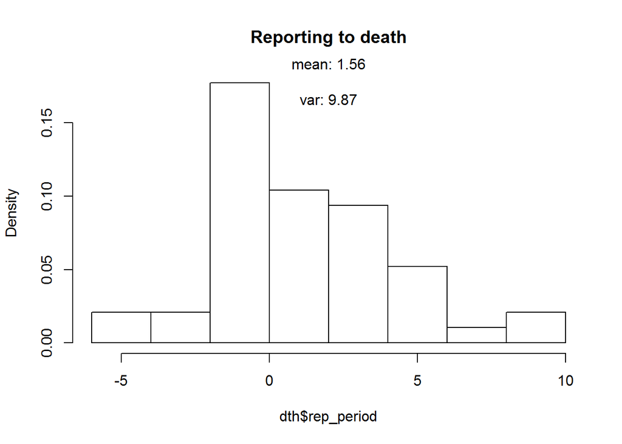

```
## [1] "gamma distribution for reporting period of values >0: "
```

```
##      shape       rate
##   2.2119780   0.6157054
##  (0.5625502) (0.1756888)
```

```
## [1] "exponential distribution for reporting period: "
```

```
##       rate
##   0.27835052
##  (0.05356858)
```

```
## [1] "skew normal distribution for reporting period: "
```

```
## Call: sn::selm(formula = data.us.death$rep_period ~ 1, family = "SN")
## Number of observations: 48
## Family: SN
## Estimation method: MLE
## Log-likelihood: -121.8496
## Parameter type: CP
##
## CP residuals:
##     Min      1Q  Median      3Q     Max
## -7.5762 -1.5762 -0.5762  1.6738  8.4238
##
## Regression coefficients
##      estimate std.err z-ratio Pr{>|z|}
## mean   1.5762  0.4461  3.5335        0
##
## Parameters of the SEC random component
##        estimate std.err
## s.d.     3.0955   0.331
## gamma1   0.3667   0.278
```

```
## Call: sn::selm(formula = data.us.death$rep_period ~ 1, family = "SN")
## Number of observations: 48
## Family: SN
## Estimation method: MLE
## Log-likelihood: -121.8496
## Parameter type: DP
##
## DP residuals:
##    Min     1Q Median     3Q    Max
## -4.639  1.361  2.361  4.611 11.361
##
## Regression coefficients
##    estimate std.err z-ratio Pr{>|z|}
## xi   -1.361   0.905  -1.504    0.133
##
## Parameters of the SEC random component
##       estimate std.err
## omega    4.267   0.758
## alpha    1.706   0.887
```

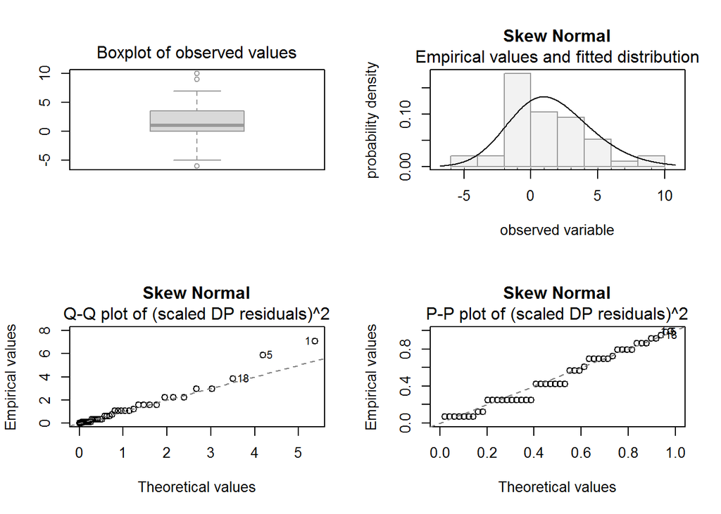

|  | mean | location | shape | scale |
| --- | --- | --- | --- | --- |
| mean | 1.58 | -1.36 | 1.71 | 4.27 |

```
## Call: sn::selm(formula = data.us.death$rep_period ~ 1, family = "ST")
## Number of observations: 48
## Family: ST
## Estimation method: MLE
## Log-likelihood: -121.0206
## Parameter type: DP
##
## DP residuals:
##     Min      1Q  Median      3Q     Max
## -5.2078  0.7922  1.7922  4.0422 10.7922
##
## Regression coefficients
##    estimate std.err z-ratio Pr{>|z|}
## xi  -0.7922  0.8026 -0.9871    0.324
##
## Parameters of the SEC random component
##       estimate std.err
## omega    3.014   0.877
## alpha    1.425   0.939
## nu       4.002   3.354
```

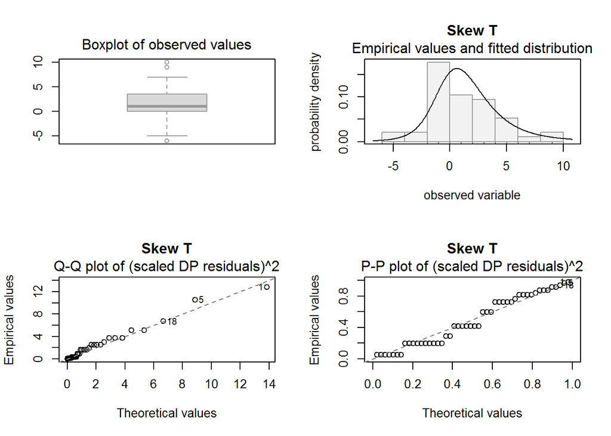

```
##     mean~     s.d.~   gamma1~   gamma2~
## 1.5488273 2.9132525 0.8848517 2.4262358
```

```
##         xi      omega      alpha         nu
## -0.7922169  3.0137951  1.4251494  4.0023943
```

### Sex and age

Histogram of US cases with exact age available

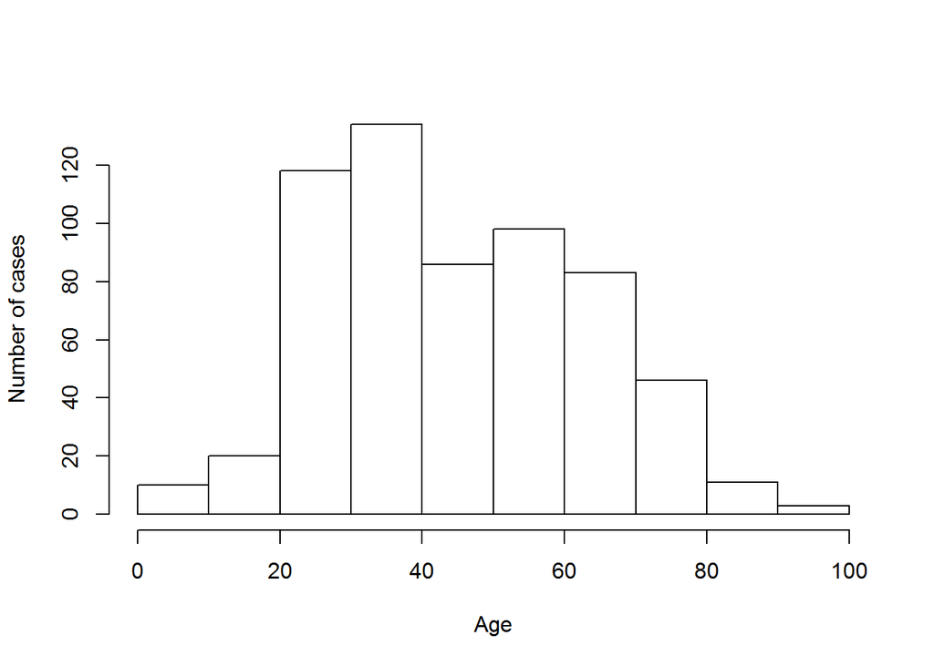

US cases by sex and 10-year age classes

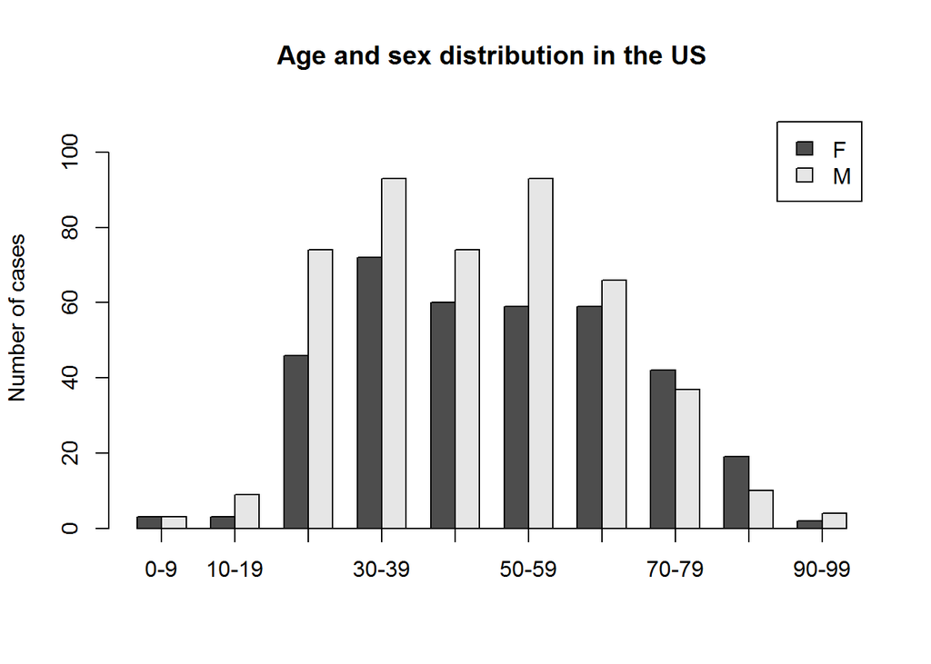

Sex and age class for states with more than 25 lines of data

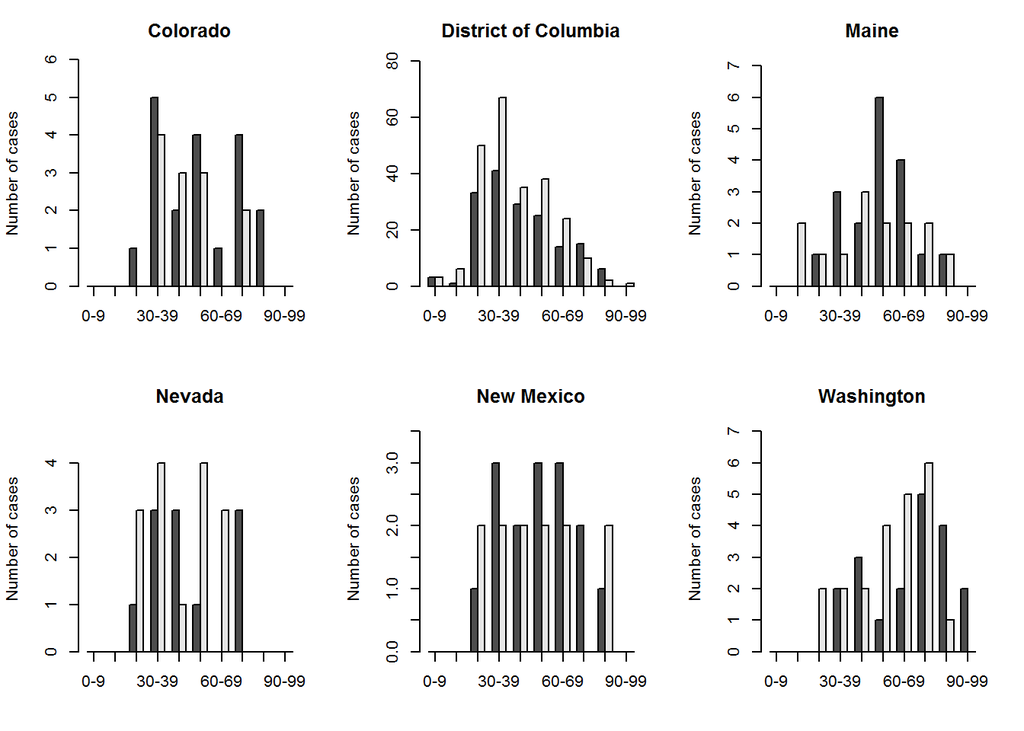